# Examining the relationship between the big-5 personality facets and implicit racial attitudes

analysis IAT

Lukas Sidler

14 Januar, 2024

# Dependancies

```r
library(tidyverse)
library(janitor)
library(stringr)
library(openxlsx)
library(tidyverse)
library(knitr)
library(kableExtra)
library(janitor)
library(scales)
library(psych)
library("htmltools")
library(report)
```

# Data

Load the processed data and apply the global exclusions.

```r
data_processed <- read_csv("../data/processed/data_processed.csv")
# Exclude participants using the master exclusion variable.
data_processed_after_exclusions <- data_processed |>
  filter(exclude_participant == "include")
```

# Create a table with the total number of participants before exclusions.

```r
data_processed |>
  count(name = "n") |>
  kable() |>
  add_header_above(header = c("before exclusion" = 1)) |>
  kable_classic(full_width = FALSE)
```

| before exclusion n |
| --- |
| 1933 |

# Create a table with the total number of participants after exclusions.

```r
# Create a table with the total number of participants after exclusions.
data_processed_after_exclusions |>
  count(name = "n") |>
  kable() |>
  add_header_above(header = c("n after exclusion" = 1)) |>
  kable_classic(full_width = FALSE)
```

| n after exclusion n |
| --- |
| 152 |

# Demographics

- Create demographics tables that summarise the mean and SD age, and the frequency and percentage of men vs women in the sample. Report the proportion of participants for which each demographics variable was available.

## Age & Sex

```r
# Take the dataset named 'data_processed_after_exclusions'
data_processed_after_exclusions |>

# Convert the 'age' column to numeric type
  mutate(age = as.numeric(age)) |>

# Calculate the mean and standard deviation (SD) of the 'age' column, ignoring NA values
  summarise(Mean = mean(age, na.rm = TRUE),
            SD = sd(age, na.rm = TRUE)) |>

# Round all the values in the dataset to 1 decimal place
  mutate_all(.funs = janitor::round_half_up, digits = 1) |>

# Convert the data to a nicely formatted table using the 'kable' function
  kable() |>

# Add a header above the table with the title "Age" spanning 2 columns
  add_header_above(header = c("Age" = 2)) |>

# Apply a classic table style to the kable output, without full width
  kable_classic(full_width = FALSE)
```

| Age Mean | Age SD |
| --- | --- |
| 30.3 | 11 |

```r
# Next section of the code

# Again, take the dataset 'data_processed_after_exclusions'
data_processed_after_exclusions |>

# Group the data by the 'sex' column
  group_by(sex) |>

# Summarise the data to count the number of occurrences in each group
  summarise(n = n()) |>

# Calculate the percentage of each sex, round it to 1 decimal place, and append a '%' sign
  mutate(Percent = paste0(round_half_up((n / sum(n)) * 100, 1), "%")) |>

# Capitalize the first letter of each value in the 'sex' column
  mutate(sex = stringr::str_to_sentence(sex)) |>

# Convert the data to a nicely formatted table using the 'kable' function
  kable() |>

# Apply a classic table style to the kable output, without full width
  kable_classic(full_width = FALSE)
```

| sex | n | Percent |
| --- | --- | --- |
| F | 90 | 59.2% |
| M | 62 | 40.8% |

# Calculate Cronbach’s alpha for each of the BFI subscales.

```r
# Agreeableness:
alpha(subset(data_processed_after_exclusions, select = c(bfi_a1, bfi_a2, bfi_a3, bfi_a4,
                                                         bfi_a5, bfi_a6, bfi_a7, bfi_a8,
                                                         bfi_a9)), check.keys = TRUE)
```

```
##
## Reliability analysis
## Call: alpha(x = subset(data_processed_after_exclusions, select = c(bfi_a1,
##     bfi_a2, bfi_a3, bfi_a4, bfi_a5, bfi_a6, bfi_a7, bfi_a8, bfi_a9)),
##     check.keys = TRUE)
##
##   raw_alpha std.alpha G6(smc) average_r S/N   ase mean   sd median_r
##       0.79       0.8    0.82      0.31   4 0.025  4.4 0.78      0.3
##
##     95% confidence boundaries
##          lower alpha upper
## Feldt     0.74  0.79  0.84
## Duhachek  0.74  0.79  0.84
##
##  Reliability if an item is dropped:
##        raw_alpha std.alpha G6(smc) average_r S/N alpha se var.r med.r
## bfi_a1      0.76      0.78    0.79      0.30 3.4    0.029 0.015  0.29
## bfi_a2      0.78      0.78    0.79      0.31 3.6    0.027 0.014  0.33
## bfi_a3      0.77      0.78    0.80      0.31 3.6    0.028 0.013  0.31
## bfi_a4      0.77      0.78    0.79      0.31 3.5    0.029 0.013  0.32
## bfi_a5      0.79      0.80    0.81      0.33 4.0    0.026 0.011  0.33
## bfi_a6      0.78      0.79    0.80      0.32 3.7    0.027 0.014  0.32
## bfi_a7      0.75      0.76    0.77      0.28 3.1    0.031 0.013  0.26
## bfi_a8      0.77      0.78    0.79      0.30 3.5    0.029 0.016  0.29
## bfi_a9      0.77      0.78    0.79      0.31 3.5    0.028 0.013  0.30
##
##  Item statistics
##         n raw.r std.r r.cor r.drop mean   sd
## bfi_a1 83  0.67  0.65  0.60   0.53  3.4 1.39
## bfi_a2 81  0.54  0.60  0.54   0.44  4.8 0.94
## bfi_a3 83  0.61  0.59  0.53   0.46  4.6 1.42
## bfi_a4 83  0.64  0.63  0.57   0.51  4.7 1.27
## bfi_a5 83  0.51  0.50  0.41   0.35  4.7 1.31
## bfi_a6 82  0.60  0.58  0.51   0.43  4.0 1.53
## bfi_a7 83  0.75  0.76  0.75   0.67  4.8 1.08
## bfi_a8 83  0.65  0.63  0.57   0.51  3.7 1.40
## bfi_a9 83  0.60  0.63  0.58   0.50  5.0 0.97
##
## Non missing response frequency for each item
##           1    2    3    4    5    6 miss
## bfi_a1 0.07 0.19 0.30 0.16 0.20 0.07 0.45
## bfi_a2 0.00 0.01 0.06 0.30 0.37 0.26 0.47
## bfi_a3 0.05 0.04 0.13 0.20 0.24 0.34 0.45
## bfi_a4 0.04 0.02 0.08 0.24 0.30 0.31 0.45
## bfi_a5 0.04 0.05 0.07 0.18 0.35 0.31 0.45
## bfi_a6 0.05 0.12 0.30 0.10 0.21 0.22 0.46
## bfi_a7 0.01 0.01 0.08 0.24 0.34 0.31 0.45
## bfi_a8 0.06 0.12 0.29 0.19 0.22 0.12 0.45
## bfi_a9 0.00 0.02 0.04 0.23 0.37 0.34 0.45
```

```r
# Conscientiousness:
alpha(subset(data_processed_after_exclusions, select = c(bfi_c1, bfi_c2, bfi_c3, bfi_c4,
                                                         bfi_c5, bfi_c6, bfi_c7, bfi_c8,
                                                         bfi_c9)), check.keys = TRUE)
```

```
##
## Reliability analysis
## Call: alpha(x = subset(data_processed_after_exclusions, select = c(bfi_c1,
##     bfi_c2, bfi_c3, bfi_c4, bfi_c5, bfi_c6, bfi_c7, bfi_c8, bfi_c9)),
##     check.keys = TRUE)
##
##   raw_alpha std.alpha G6(smc) average_r S/N   ase mean   sd median_r
##       0.82      0.83    0.85      0.35 4.8 0.022  4.4 0.79     0.35
##
##     95% confidence boundaries
##          lower alpha upper
## Feldt     0.77  0.82  0.86
## Duhachek  0.77  0.82  0.86
##
##  Reliability if an item is dropped:
##        raw_alpha std.alpha G6(smc) average_r S/N alpha se var.r med.r
## bfi_c1      0.80      0.81    0.82      0.35 4.3    0.024 0.015  0.35
## bfi_c2      0.79      0.81    0.82      0.35 4.3    0.025 0.023  0.34
## bfi_c3      0.79      0.79    0.80      0.32 3.8    0.025 0.015  0.34
## bfi_c4      0.81      0.82    0.84      0.37 4.7    0.023 0.021  0.36
## bfi_c5      0.80      0.82    0.83      0.36 4.5    0.024 0.020  0.34
## bfi_c6      0.78      0.79    0.82      0.33 3.9    0.026 0.020  0.31
## bfi_c7      0.79      0.80    0.82      0.33 4.0    0.026 0.022  0.33
## bfi_c8      0.81      0.82    0.84      0.36 4.5    0.023 0.019  0.35
## bfi_c9      0.81      0.82    0.84      0.37 4.6    0.023 0.020  0.35
##
##  Item statistics
##         n raw.r std.r r.cor r.drop mean   sd
## bfi_c1 67  0.58  0.64  0.61   0.49  5.1 0.88
## bfi_c2 67  0.70  0.64  0.59   0.56  4.0 1.50
## bfi_c3 67  0.72  0.78  0.78   0.66  5.2 0.94
## bfi_c4 67  0.58  0.55  0.46   0.43  3.4 1.42
## bfi_c5 67  0.64  0.59  0.53   0.49  4.0 1.46
## bfi_c6 67  0.74  0.76  0.73   0.65  4.7 1.28
## bfi_c7 66  0.72  0.73  0.69   0.62  4.7 1.21
## bfi_c8 67  0.54  0.58  0.51   0.43  4.8 1.01
## bfi_c9 67  0.59  0.56  0.48   0.44  3.4 1.36
##
## Non missing response frequency for each item
##           1    2    3    4    5    6 miss
## bfi_c1 0.00 0.01 0.01 0.21 0.40 0.36 0.56
## bfi_c2 0.06 0.15 0.18 0.15 0.31 0.15 0.56
## bfi_c3 0.00 0.01 0.03 0.16 0.28 0.51 0.56
## bfi_c4 0.04 0.19 0.45 0.07 0.09 0.15 0.56
## bfi_c5 0.03 0.15 0.24 0.16 0.22 0.19 0.56
## bfi_c6 0.01 0.06 0.10 0.19 0.30 0.33 0.56
## bfi_c7 0.02 0.06 0.08 0.21 0.38 0.26 0.57
## bfi_c8 0.00 0.04 0.03 0.25 0.40 0.27 0.56
## bfi_c9 0.09 0.18 0.27 0.18 0.25 0.03 0.56
```

```r
# Extraversion:
alpha(subset(data_processed_after_exclusions, select = c(bfi_e1, bfi_e2, bfi_e3, bfi_e4,
                                                         bfi_e5, bfi_e6, bfi_e7, bfi_e8)),
      check.keys = TRUE)
```

```
##
## Reliability analysis
## Call: alpha(x = subset(data_processed_after_exclusions, select = c(bfi_e1,
##     bfi_e2, bfi_e3, bfi_e4, bfi_e5, bfi_e6, bfi_e7, bfi_e8)),
##     check.keys = TRUE)
##
##   raw_alpha std.alpha G6(smc) average_r S/N   ase mean   sd median_r
##       0.82      0.81    0.83      0.35 4.3 0.022  3.8 0.85     0.36
##
##     95% confidence boundaries
##          lower alpha upper
## Feldt     0.77  0.82  0.86
## Duhachek  0.77  0.82  0.86
##
##  Reliability if an item is dropped:
##        raw_alpha std.alpha G6(smc) average_r S/N alpha se var.r med.r
## bfi_e1      0.76      0.76    0.78      0.31 3.1    0.030 0.029  0.30
## bfi_e2      0.80      0.79    0.81      0.35 3.8    0.025 0.026  0.33
## bfi_e3      0.82      0.82    0.83      0.39 4.5    0.022 0.029  0.39
## bfi_e4      0.81      0.81    0.82      0.38 4.3    0.023 0.031  0.39
## bfi_e5      0.77      0.76    0.78      0.32 3.2    0.029 0.028  0.33
## bfi_e6      0.81      0.81    0.83      0.38 4.2    0.023 0.037  0.42
## bfi_e7      0.80      0.80    0.81      0.36 3.9    0.024 0.030  0.31
## bfi_e8      0.78      0.78    0.80      0.33 3.5    0.027 0.032  0.33
##
##  Item statistics
##         n raw.r std.r r.cor r.drop mean  sd
## bfi_e1 67  0.84  0.84  0.84   0.76  4.2 1.4
## bfi_e2 67  0.65  0.65  0.60   0.52  3.1 1.3
## bfi_e3 67  0.49  0.51  0.40   0.33  4.0 1.2
## bfi_e4 66  0.52  0.55  0.46   0.39  4.5 1.1
## bfi_e5 67  0.81  0.80  0.79   0.72  3.1 1.3
## bfi_e6 67  0.57  0.56  0.46   0.41  4.4 1.4
## bfi_e7 67  0.65  0.63  0.57   0.50  2.9 1.4
## bfi_e8 67  0.74  0.74  0.70   0.63  4.3 1.2
##
## Non missing response frequency for each item
##           1    2    3    4    5    6 miss
## bfi_e1 0.03 0.10 0.16 0.27 0.21 0.22 0.56
## bfi_e2 0.10 0.19 0.43 0.10 0.10 0.06 0.56
## bfi_e3 0.01 0.09 0.22 0.25 0.34 0.07 0.56
## bfi_e4 0.03 0.03 0.11 0.23 0.50 0.11 0.57
## bfi_e5 0.13 0.19 0.36 0.13 0.15 0.03 0.56
## bfi_e6 0.06 0.06 0.07 0.25 0.36 0.19 0.56
## bfi_e7 0.13 0.31 0.33 0.06 0.09 0.07 0.56
## bfi_e8 0.03 0.04 0.18 0.25 0.33 0.16 0.56
```

```r
# Neuroticism:
alpha(subset(data_processed_after_exclusions, select = c(bfi_n1, bfi_n2, bfi_n3, bfi_n4,
                                                         bfi_n5, bfi_n6, bfi_n7, bfi_n8)),
      check.keys = TRUE)
```

```
##
## Reliability analysis
## Call: alpha(x = subset(data_processed_after_exclusions, select = c(bfi_n1,
##     bfi_n2, bfi_n3, bfi_n4, bfi_n5, bfi_n6, bfi_n7, bfi_n8)),
##     check.keys = TRUE)
##
##   raw_alpha std.alpha G6(smc) average_r S/N   ase mean   sd median_r
##        0.8       0.8    0.82      0.34 4.1 0.024  3.2 0.86     0.38
##
##     95% confidence boundaries
##          lower alpha upper
## Feldt     0.75   0.8  0.85
## Duhachek  0.75   0.8  0.85
##
##  Reliability if an item is dropped:
##        raw_alpha std.alpha G6(smc) average_r S/N alpha se  var.r med.r
## bfi_n1      0.77      0.77    0.78      0.33 3.4    0.028 0.0229  0.32
## bfi_n2      0.77      0.77    0.78      0.33 3.4    0.028 0.0215  0.32
## bfi_n3      0.78      0.78    0.79      0.34 3.6    0.027 0.0231  0.39
## bfi_n4      0.76      0.76    0.76      0.31 3.2    0.030 0.0173  0.31
## bfi_n5      0.77      0.78    0.78      0.33 3.5    0.028 0.0259  0.38
## bfi_n6      0.83      0.83    0.83      0.40 4.7    0.021 0.0095  0.40
## bfi_n7      0.78      0.78    0.79      0.34 3.5    0.027 0.0233  0.38
## bfi_n8      0.77      0.77    0.78      0.33 3.4    0.028 0.0227  0.38
##
##  Item statistics
##         n raw.r std.r r.cor r.drop mean  sd
## bfi_n1 67  0.70  0.70  0.64   0.57  2.8 1.4
## bfi_n2 67  0.68  0.69  0.64   0.56  2.8 1.2
## bfi_n3 67  0.64  0.64  0.58   0.52  4.1 1.2
## bfi_n4 67  0.76  0.75  0.74   0.65  3.6 1.5
## bfi_n5 67  0.67  0.67  0.62   0.55  2.3 1.2
## bfi_n6 67  0.39  0.39  0.24   0.20  3.9 1.4
## bfi_n7 67  0.65  0.66  0.59   0.52  2.4 1.3
## bfi_n8 67  0.71  0.69  0.64   0.58  3.4 1.4
##
## Non missing response frequency for each item
##           1    2    3    4    5    6 miss
## bfi_n1 0.19 0.33 0.13 0.24 0.06 0.04 0.56
## bfi_n2 0.12 0.31 0.34 0.10 0.09 0.03 0.56
## bfi_n3 0.04 0.06 0.13 0.40 0.27 0.09 0.56
## bfi_n4 0.12 0.15 0.10 0.34 0.18 0.10 0.56
## bfi_n5 0.25 0.43 0.13 0.13 0.01 0.03 0.56
## bfi_n6 0.06 0.16 0.04 0.40 0.21 0.12 0.56
## bfi_n7 0.27 0.37 0.16 0.10 0.07 0.01 0.56
## bfi_n8 0.10 0.16 0.24 0.28 0.13 0.07 0.56
```

```r
# Opennes:
alpha(subset(data_processed_after_exclusions, select = c(bfi_o1, bfi_o2, bfi_o3, bfi_o4,
                                                         bfi_o5, bfi_o6, bfi_o7, bfi_o8,
                                                         bfi_o9, bfi_o10)), check.keys = TRUE)
```

```
##
## Reliability analysis
## Call: alpha(x = subset(data_processed_after_exclusions, select = c(bfi_o1,
##     bfi_o2, bfi_o3, bfi_o4, bfi_o5, bfi_o6, bfi_o7, bfi_o8, bfi_o9,
##     bfi_o10)), check.keys = TRUE)
##
##   raw_alpha std.alpha G6(smc) average_r S/N   ase mean   sd median_r
##       0.78       0.8    0.85      0.28 3.9 0.028  4.6 0.69     0.28
##
##     95% confidence boundaries
##          lower alpha upper
## Feldt     0.72  0.78  0.82
## Duhachek  0.72  0.78  0.83
##
##  Reliability if an item is dropped:
##         raw_alpha std.alpha G6(smc) average_r S/N alpha se var.r med.r
## bfi_o1       0.75      0.77    0.82      0.27 3.4    0.031 0.028  0.28
## bfi_o2       0.76      0.78    0.84      0.28 3.5    0.030 0.036  0.26
## bfi_o3       0.75      0.77    0.82      0.27 3.4    0.031 0.030  0.28
## bfi_o4       0.75      0.77    0.83      0.27 3.4    0.032 0.035  0.27
## bfi_o5       0.74      0.76    0.82      0.26 3.2    0.032 0.027  0.28
## bfi_o6       0.75      0.78    0.83      0.29 3.6    0.031 0.030  0.30
## bfi_o7       0.79      0.80    0.85      0.31 4.0    0.026 0.027  0.31
## bfi_o8       0.75      0.77    0.82      0.27 3.4    0.030 0.030  0.28
## bfi_o9       0.76      0.79    0.84      0.29 3.7    0.030 0.030  0.28
## bfi_o10      0.77      0.79    0.83      0.29 3.8    0.029 0.023  0.28
##
##  Item statistics
##          n raw.r std.r r.cor r.drop mean   sd
## bfi_o1  83  0.63  0.65  0.63   0.53  4.7 1.06
## bfi_o2  83  0.58  0.61  0.54   0.50  5.5 0.72
## bfi_o3  83  0.63  0.65  0.62   0.50  4.5 1.20
## bfi_o4  83  0.64  0.64  0.59   0.53  4.9 1.15
## bfi_o5  83  0.67  0.70  0.68   0.57  4.6 1.13
## bfi_o6  83  0.59  0.57  0.52   0.46  4.7 1.24
## bfi_o7  82  0.42  0.43  0.34   0.23  4.0 1.38
## bfi_o8  82  0.58  0.64  0.60   0.49  5.0 0.84
## bfi_o9  82  0.59  0.54  0.48   0.42  4.1 1.51
## bfi_o10 83  0.57  0.52  0.48   0.39  3.7 1.51
##
## Non missing response frequency for each item
##            1    2    3    4    5    6 miss
## bfi_o1  0.00 0.04 0.08 0.29 0.34 0.25 0.45
## bfi_o2  0.00 0.00 0.01 0.10 0.28 0.61 0.45
## bfi_o3  0.04 0.02 0.06 0.36 0.28 0.24 0.45
## bfi_o4  0.02 0.01 0.08 0.13 0.40 0.35 0.45
## bfi_o5  0.02 0.04 0.05 0.33 0.36 0.20 0.45
## bfi_o6  0.02 0.04 0.07 0.24 0.29 0.34 0.45
## bfi_o7  0.01 0.12 0.29 0.17 0.21 0.20 0.46
## bfi_o8  0.00 0.00 0.02 0.26 0.37 0.35 0.46
## bfi_o9  0.06 0.10 0.17 0.21 0.23 0.23 0.46
## bfi_o10 0.12 0.11 0.16 0.24 0.28 0.10 0.45
```

# Create series of histograms of the distribution of scores on each of the BFI subscales

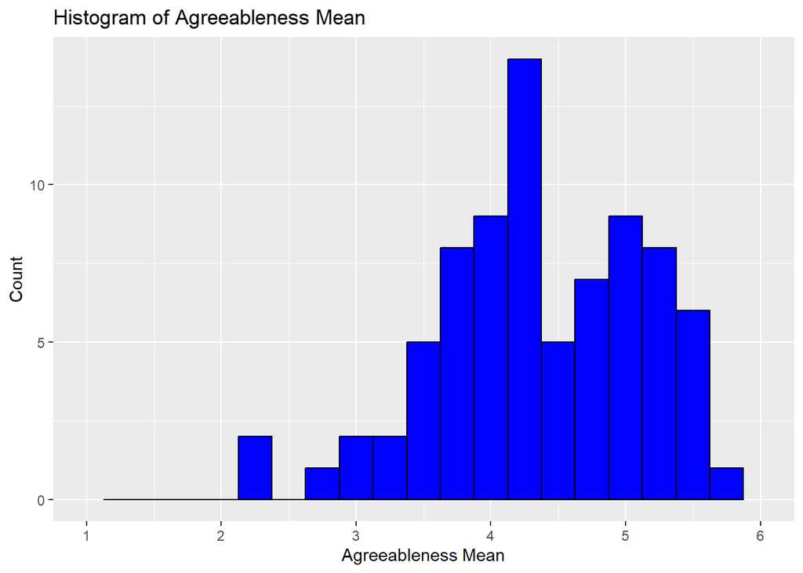

```r
#Histograms for all the BFI- Subscales
library(ggplot2)

ggplot(data_processed_after_exclusions, aes(x=agreeableness_mean)) +
  geom_histogram(binwidth = 0.25, fill="blue", color="black") +
  labs(title="Histogram of Agreeableness Mean", x="Agreeableness Mean", y="Count") +
  scale_x_continuous(limits = c(1, 6), breaks=1:6)
```

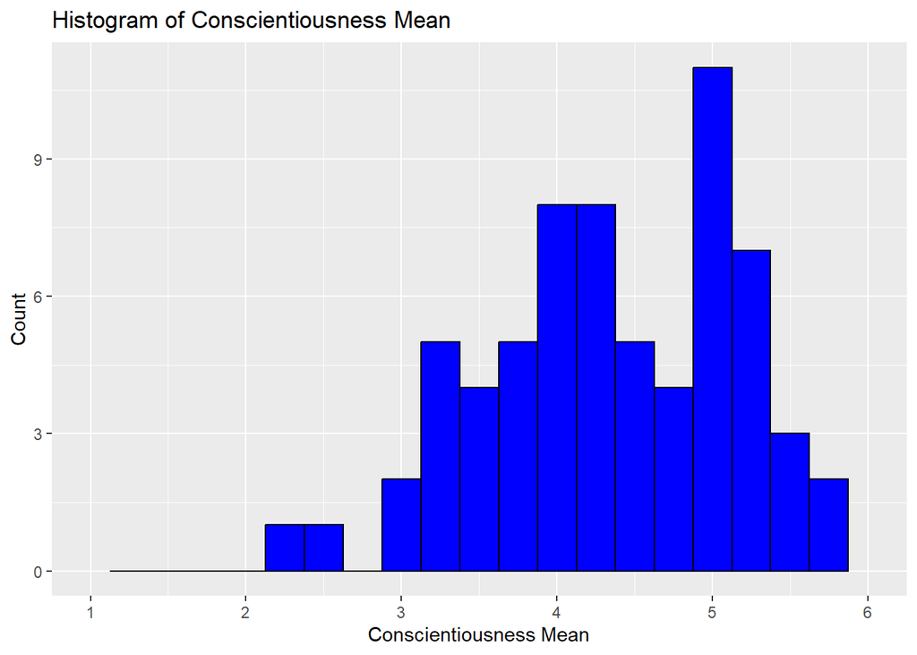

```r
# Histogram for conscientiousness_mean
ggplot(data_processed_after_exclusions, aes(x=conscientiousness_mean)) +
  geom_histogram(binwidth = 0.25, fill="blue", color="black") +
  labs(title="Histogram of Conscientiousness Mean", x="Conscientiousness Mean", y="Count") +
  scale_x_continuous(limits = c(1, 6), breaks=1:6)
```

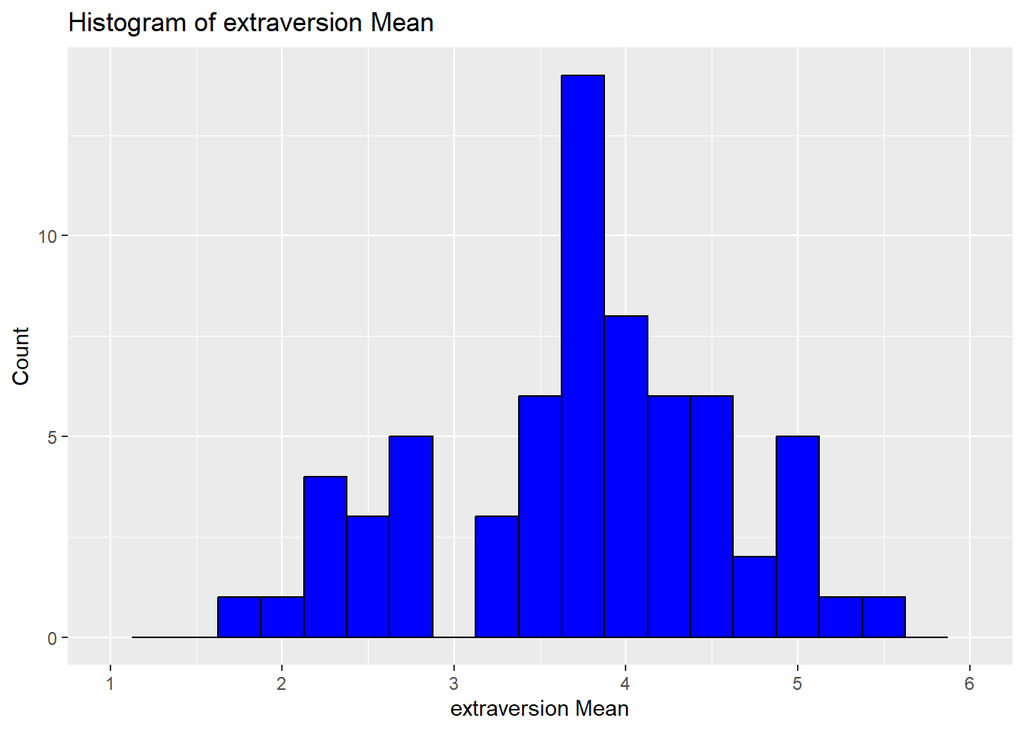

```r
# Histogram for extraversion
ggplot(data_processed_after_exclusions, aes(x=extraversion_mean)) +
  geom_histogram(binwidth = 0.25, fill="blue", color="black") +
  labs(title="Histogram of extraversion Mean", x="extraversion Mean", y="Count") +
  scale_x_continuous(limits = c(1, 6), breaks=1:6)
```

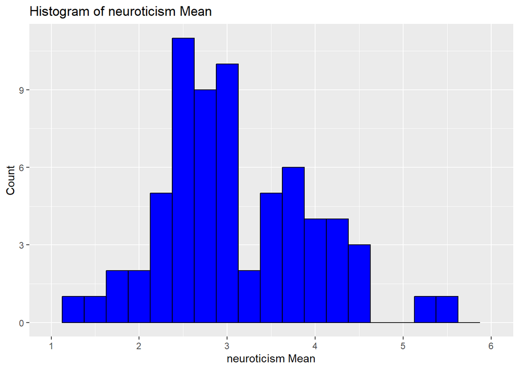

```r
# Histogram for neuroticism
ggplot(data_processed_after_exclusions, aes(x=neuroticism_mean)) +
  geom_histogram(binwidth = 0.25, fill="blue", color="black") +
  labs(title="Histogram of neuroticism Mean", x="neuroticism Mean", y="Count") +
  scale_x_continuous(limits = c(1, 6), breaks=1:6)
```

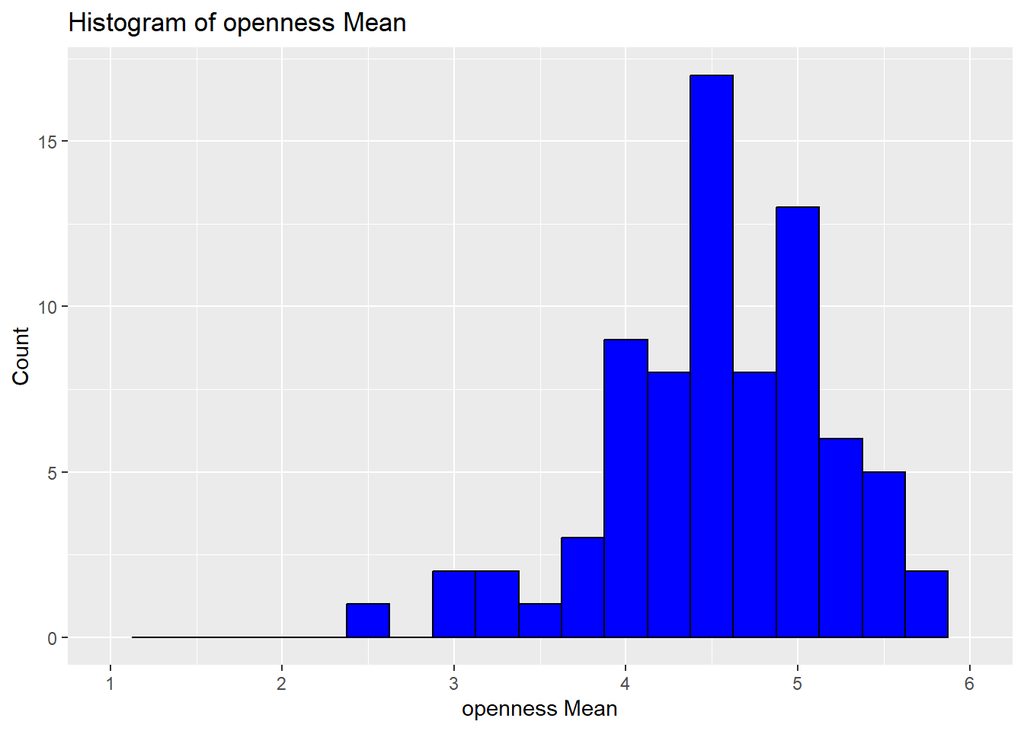

```r
# Histogram for openness
ggplot(data_processed_after_exclusions, aes(x=openness_mean)) +
  geom_histogram(binwidth = 0.25, fill="blue", color="black") +
  labs(title="Histogram of openness Mean", x="openness Mean", y="Count") +
  scale_x_continuous(limits = c(1, 6), breaks=1:6)
```

# Create series of histograms of the distribution of scores for the IAT.

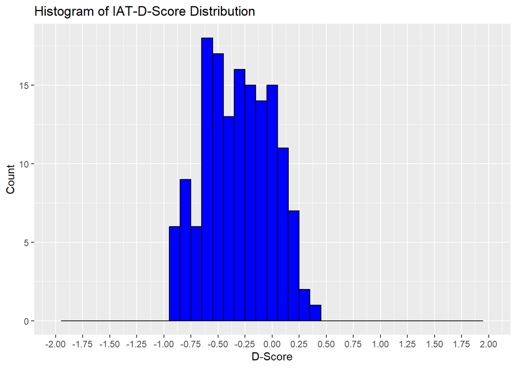

```r
library(ggplot2)

ggplot(data_processed_after_exclusions, aes(x=D)) +
  geom_histogram(binwidth = 0.1, fill="blue", color="black", na.rm = TRUE) +
  labs(title="Histogram of IAT-D-Score Distribution", x="D-Score", y="Count") +
  scale_x_continuous(
    limits = c(-2, 2),
    breaks = seq(-2, 2, by = 0.25))
```

# Create a table with a correlation matrix

of the Pearson’s r correlations between the IAT and the BFI subscales rounded to two decimal places.

```r
# Load the necessary library
library(Hmisc)
# Subset the dataframe to include only the relevant variables
data_correlation <- data_processed_after_exclusions[c("D", "agreeableness_mean", "conscientiousness_mean", "extraversion_mean", "neuroticism_mean", "openness_mean")]

# Use the cor function with the method "pearson" and use the use="pairwise.complete.obs"
# to ensure that only pairwise complete observations are used for each correlation
cor_matrix <- cor(data_correlation, method = "pearson", use = "pairwise.complete.obs")

# Round the correlation matrix to two decimal places
cor_matrix_rounded <- round(cor_matrix, 2)

# Print the correlation matrix
print(cor_matrix_rounded)
```

```
##                            D agreeableness_mean conscientiousness_mean
## D                       1.00               0.02                   0.01
## agreeableness_mean      0.02               1.00                     NA
## conscientiousness_mean  0.01                 NA                   1.00
## extraversion_mean       0.01                 NA                   0.11
## neuroticism_mean        0.12                 NA                  -0.35
## openness_mean          -0.07               0.16                     NA
##                        extraversion_mean neuroticism_mean openness_mean
## D                                   0.01             0.12         -0.07
## agreeableness_mean                    NA               NA          0.16
## conscientiousness_mean              0.11            -0.35            NA
## extraversion_mean                   1.00            -0.10            NA
## neuroticism_mean                   -0.10             1.00            NA
## openness_mean                         NA               NA          1.00
```

# Run a t-test

to test the hypothesis that men and women differ on their scores on the IAT. Report and interpret the results using {report}.

```r
# Install and load the report package
if (!requireNamespace("report", quietly = TRUE)) {
  install.packages("report")
}
library(report)

# Run the t-test
t_test_result <- t.test(D ~ sex, data = data_processed_after_exclusions)

# Generate a report
report_result <- report(t_test_result)
# Print the report
print(report_result)
```

```
## Effect sizes were labelled following Cohen's (1988) recommendations.
##
## The Welch Two Sample t-test testing the difference of D by sex (mean in group f
## = -0.29, mean in group m = -0.36) suggests that the effect is positive,
## statistically not significant, and small (difference = 0.07, 95% CI [-0.04,
## 0.17], t(119.05) = 1.25, p = 0.214; Cohen's d = 0.23, 95% CI [-0.13, 0.59])
```

# Run a series of regressions

to test the hypotheses that each BFI subscale predicts IAT scores. Run separate regressions for each subscale rather than a multiple regression. Report and interpret the results using {report}.

```r
# List of BFI subscales
bfi_subscales <- c("agreeableness_mean", "conscientiousness_mean", "extraversion_mean", "neuroticism_mean", "openness_mean")

# Loop through each BFI subscale and run a regression
for (subscale in bfi_subscales) {
  regression_formula <- as.formula(paste("D ~", subscale))
  regression_result <- lm(regression_formula, data = data_processed_after_exclusions)

  # Report the results
  report_result <- report(regression_result)
  print(paste("Regression result for", subscale, ":"))
  print(report_result)
}
```

```
## [1] "Regression result for agreeableness_mean :"
## We fitted a linear model (estimated using OLS) to predict D with
## agreeableness_mean (formula: D ~ agreeableness_mean). The model explains a
## statistically not significant and very weak proportion of variance (R2 =
## 2.85e-04, F(1, 78) = 0.02, p = 0.882, adj. R2 = -0.01). The model's intercept,
## corresponding to agreeableness_mean = 0, is at -0.33 (95% CI [-0.74, 0.09],
## t(78) = -1.58, p = 0.119). Within this model:
##
##   - The effect of agreeableness mean is statistically non-significant and
## positive (beta = 6.95e-03, 95% CI [-0.09, 0.10], t(78) = 0.15, p = 0.882; Std.
## beta = 0.02, 95% CI [-0.21, 0.24])
##
## Standardized parameters were obtained by fitting the model on a standardized
## version of the dataset. 95% Confidence Intervals (CIs) and p-values were
## computed using a Wald t-distribution approximation.
## [1] "Regression result for conscientiousness_mean :"
## We fitted a linear model (estimated using OLS) to predict D with
## conscientiousness_mean (formula: D ~ conscientiousness_mean). The model
## explains a statistically not significant and very weak proportion of variance
## (R2 = 1.50e-04, F(1, 64) = 9.60e-03, p = 0.922, adj. R2 = -0.02). The model's
## intercept, corresponding to conscientiousness_mean = 0, is at -0.36 (95% CI
## [-0.77, 0.05], t(64) = -1.75, p = 0.085). Within this model:
##
##   - The effect of conscientiousness mean is statistically non-significant and
## positive (beta = 4.56e-03, 95% CI [-0.09, 0.10], t(64) = 0.10, p = 0.922; Std.
## beta = 0.01, 95% CI [-0.24, 0.26])
##
## Standardized parameters were obtained by fitting the model on a standardized
## version of the dataset. 95% Confidence Intervals (CIs) and p-values were
## computed using a Wald t-distribution approximation.
## [1] "Regression result for extraversion_mean :"
## We fitted a linear model (estimated using OLS) to predict D with
## extraversion_mean (formula: D ~ extraversion_mean). The model explains a
## statistically not significant and very weak proportion of variance (R2 =
## 1.11e-04, F(1, 64) = 7.08e-03, p = 0.933, adj. R2 = -0.02). The model's
## intercept, corresponding to extraversion_mean = 0, is at -0.35 (95% CI [-0.69,
## -8.77e-03], t(64) = -2.05, p = 0.045). Within this model:
##
##   - The effect of extraversion mean is statistically non-significant and positive
## (beta = 3.67e-03, 95% CI [-0.08, 0.09], t(64) = 0.08, p = 0.933; Std. beta =
```

[output cut: 20 more lines]

```
## [1] "Regression result for openness_mean :"
## We fitted a linear model (estimated using OLS) to predict D with openness_mean
## (formula: D ~ openness_mean). The model explains a statistically not
## significant and very weak proportion of variance (R2 = 4.74e-03, F(1, 78) =
## 0.37, p = 0.544, adj. R2 = -8.02e-03). The model's intercept, corresponding to
## openness_mean = 0, is at -0.15 (95% CI [-0.64, 0.33], t(78) = -0.62, p =
## 0.536). Within this model:
##
##   - The effect of openness mean is statistically non-significant and negative
## (beta = -0.03, 95% CI [-0.14, 0.07], t(78) = -0.61, p = 0.544; Std. beta =
## -0.07, 95% CI [-0.29, 0.16])
##
## Standardized parameters were obtained by fitting the model on a standardized
## version of the dataset. 95% Confidence Intervals (CIs) and p-values were
## computed using a Wald t-distribution approximation.
```

# Create series of scatter plots of how BFI subscale scores predict IAT scores.

Add regression lines. These plots therefore illustrate the same results as the regressions above. Make the plots presentable and publication quality- you may decide the details of this with one exception: Extreme scores on the IAT (defined as participants whose scores in the top and bottom 10% of IAT scores) should use a triangular shape rather than a dot. A single combined plot should be created, containing 5 component plots, with the personality facet being examined in each clearly labelled. This plot should be printed in the html file but also saved to disk as both png/pdf.

### Note: The Png and PDF version of the plots look way better than what is printed in here, so check those.

[figure not shown]

```r
library(ggplot2)
library(dplyr)
library(gridExtra)
# Identify the top and bottom 10% of IAT scores
threshold_high <- quantile(data_processed_after_exclusions$D, 0.9, na.rm = TRUE)
threshold_low <- quantile(data_processed_after_exclusions$D, 0.1, na.rm = TRUE)

# Create a new column for shape
data_processed_after_exclusions$shape <- ifelse(data_processed_after_exclusions$D >= threshold_high | data_processed_after_exclusions$D <= threshold_low, "triangle", "circle")

# List of BFI subscales
bfi_subscales <- c("agreeableness_mean", "conscientiousness_mean", "extraversion_mean", "neuroticism_mean", "openness_mean")

# Create a list to store plots
plots_list <- list()

# Generate plots for each subscale
for (subscale in bfi_subscales) {
  p <- ggplot(data_processed_after_exclusions, aes_string(x=subscale, y="D", shape="shape")) +
    geom_jitter(width = 0.1, height = 0, size = 2.5, alpha = 0.6) +
    geom_smooth(method="lm", se=FALSE, aes(group = 1)) +
    labs(
      title=paste("IAT scores vs", subscale),
      x=subscale,
      y="IAT Score",
      caption = "Note: Points have been jittered horizontally for visualization purposes, extreme values are represented by triangles."
    ) +
    scale_shape_manual(values=c(circle=16, triangle=17)) +
    theme(legend.position = "none")

  plots_list[[subscale]] <- p
}
# Combine the plots into a single plot
combined_plot <- do.call(grid.arrange, c(plots_list, ncol=1))
```

```r
# Save the plot
ggsave("bfi_iat_relationship.png", combined_plot, width = 10, height = 30)
ggsave("bfi_iat_relationship.pdf", combined_plot, width = 10, height = 30)

# Print the plot for the HTML file
print(combined_plot)
```

```r
#Note: The Png and PDF version of the plots look way better than what is printed in here, so check those.
```

## Combine these scatter plots into one ggplot

object using {patchwork} and print the combined plot in your .Rmd and .html. Save the combined plot to disk as a .pdf and .png in the “communications” folder.

### Note: The Png and PDF version of the plots look way better than what is printed in here, so check those.

```r
# Install and load the patchwork package if you haven't already
if (!requireNamespace("patchwork", quietly = TRUE)) {
  install.packages("patchwork")
}
library(patchwork)
```

[figure not shown]

```r
# Identify the top and bottom 10% of IAT scores
threshold_high <- quantile(data_processed_after_exclusions$D, 0.9, na.rm = TRUE)
threshold_low <- quantile(data_processed_after_exclusions$D, 0.1, na.rm = TRUE)

# Create a new column for shape
data_processed_after_exclusions$shape <- ifelse(data_processed_after_exclusions$D >= threshold_high | data_processed_after_exclusions$D <= threshold_low, "triangle", "circle")

# List of BFI subscales
bfi_subscales <- c("agreeableness_mean", "conscientiousness_mean", "extraversion_mean", "neuroticism_mean", "openness_mean")

# Create a list to store plots
plots_list <- list()

# Generate plots for each subscale
for (subscale in bfi_subscales) {
  p <- ggplot(data_processed_after_exclusions, aes_string(x=subscale, y="D", shape="shape")) +
    geom_jitter(width = 0.1, height = 0, size = 2.5, alpha = 0.6) +
    geom_smooth(method="lm", se=FALSE, aes(group = 1)) +
    labs(
      title=paste("IAT scores vs", subscale),
      x=subscale,
      y="IAT Score",
      caption = "Note: Points have been jittered horizontally for visualization purposes, extreme values are represented by triangles."
    ) +
    scale_shape_manual(values=c(circle=16, triangle=17)) +
    theme(legend.position = "none")

  plots_list[[subscale]] <- p
}


# Combine the plots into a single plot using patchwork
combined_plot <- patchwork::wrap_plots(plots_list, ncol = 1)

# Print the combined plot for the R Markdown (.Rmd) and HTML file
print(combined_plot)
```

```r
# Save the combined plot to the "communications" folder as .pdf and .png
ggsave("../communications/bfi_iat_relationship.png", combined_plot, width = 10, height = 30)
ggsave("../communications/bfi_iat_relationship.pdf", combined_plot, width = 10, height = 30)
#Note: The Png and PDF version of the plots look way better than what is printed in here, so check those.
```